# MACHINE LEARNING - ENSEMBLE TECHNIQUES

## Model building - Bagging

- Build bagging classifier, random forest and decision tree.

### Model performance evaluation and improvement

- Comment on which metric is right for model performance evaluation and why? - Comment on model performance - Can model performance be improved? check and comment

**Before building the model, let's create functions to calculate different metrics- Accuracy, Recall and Precision and plot the confusion matrix.**

```python
## Function to create confusion matrix
def make_confusion_matrix(model,y_actual,labels=[1, 0]):
    '''
    model : classifier to predict values of X
    y_actual : ground truth

    '''
    y_predict = model.predict(X_test)
    cm=metrics.confusion_matrix( y_actual, y_predict, labels=[0, 1])
    df_cm = pd.DataFrame(cm, index = [i for i in ["Actual - No","Actual - Yes"]],
                  columns = [i for i in ['Predicted - No','Predicted - Yes']])
    group_counts = ["{0:0.0f}".format(value) for value in
                cm.flatten()]
    group_percentages = ["{0:.2%}".format(value) for value in
                         cm.flatten()/np.sum(cm)]
    labels = [f"{v1}\n{v2}" for v1, v2 in
              zip(group_counts,group_percentages)]
    labels = np.asarray(labels).reshape(2,2)
    plt.figure(figsize = (10,7))
    sns.heatmap(df_cm, annot=labels,fmt='')
    plt.ylabel('True label')
    plt.xlabel('Predicted label')
```

```python
##  Function to calculate different metric scores of the model - Accuracy, Recall and Precision
def get_metrics_score(model,flag=True):
    '''
    model : classifier to predict values of X

    '''
    # defining an empty list to store train and test results
    score_list=[]

    #Predicting on train and tests
    pred_train = model.predict(X_train)
    pred_test = model.predict(X_test)

    #Accuracy of the model
    train_acc = model.score(X_train,y_train)
    test_acc = model.score(X_test,y_test)

    #Recall of the model
    train_recall = metrics.recall_score(y_train,pred_train)
    test_recall = metrics.recall_score(y_test,pred_test)

    #Precision of the model
    train_precision = metrics.precision_score(y_train,pred_train)
    test_precision = metrics.precision_score(y_test,pred_test)

    score_list.extend((train_acc,test_acc,train_recall,test_recall,train_precision,test_precision))

    # If the flag is set to True then only the following print statements will be dispayed. The default value is set to True.
    if flag == True:
        print("Accuracy on training set : ",model.score(X_train,y_train))
        print("Accuracy on test set : ",model.score(X_test,y_test))
        print("Recall on training set : ",metrics.recall_score(y_train,pred_train))
        print("Recall on test set : ",metrics.recall_score(y_test,pred_test))
        print("Precision on training set : ",metrics.precision_score(y_train,pred_train))
        print("Precision on test set : ",metrics.precision_score(y_test,pred_test))

    return score_list # returning the list with train and test scores
```

## Building the model

- We are going to build 3 ensemble models here - Bagging Classifier, Random Forest Classifier and Decision Tree.
- First, let's build these models with default parameters and then use hyperparameter tuning to optimize the model performance.
- We will calculate all three metrics - Accuracy, Precision and Recall but the metric of interest here is recall.
- 'Recall' - It gives the ratio of True positives to Actual positives, so high Recall implies low false negatives, i.e. low chances of predicting a ProdTaken as non ProdTaken

### Bagging Classifier

```python
#base_estimator for bagging classifier is a decision tree by default
bagging_estimator=BaggingClassifier(random_state=1)
bagging_estimator.fit(X_train,y_train)
```

```
BaggingClassifier(random_state=1)
```

```python
#Using above defined function to get accuracy, recall and precision on train and test set
bagging_estimator_score=get_metrics_score(bagging_estimator)
```

```
Accuracy on training set :  0.9913464866735895
Accuracy on test set :  0.8950766747376917
Recall on training set :  0.9562043795620438
Recall on test set :  0.606425702811245
Precision on training set :  0.9980952380952381
Precision on test set :  0.825136612021858
```

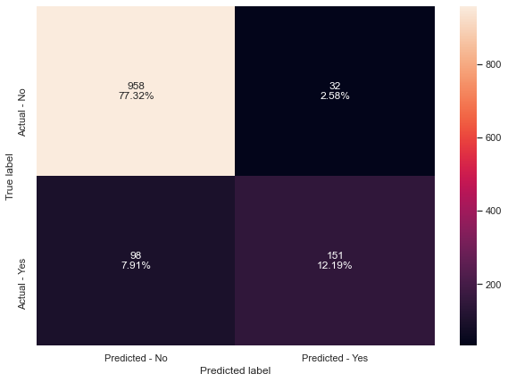

```python
make_confusion_matrix(bagging_estimator,y_test)
```

### Random Forest Classifier

```python
#Train the random forest classifier
rf_estimator=RandomForestClassifier(random_state=1)
rf_estimator.fit(X_train,y_train)
```

```
RandomForestClassifier(random_state=1)
```

```python
#Using above defined function to get accuracy, recall and precision on train and test set
rf_estimator_score=get_metrics_score(rf_estimator)
```

```
Accuracy on training set :  1.0
Accuracy on test set :  0.8966908797417272
Recall on training set :  1.0
Recall on test set :  0.5622489959839357
Precision on training set :  1.0
Precision on test set :  0.8805031446540881
```

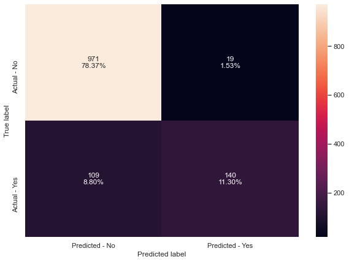

```python
make_confusion_matrix(rf_estimator,y_test)
```

### Decision Tree Model

```python
#Train the Decision Tree
dtree=DecisionTreeClassifier(random_state=1)
dtree.fit(X_train,y_train)
```

```
DecisionTreeClassifier(random_state=1)
```

```python
#Using above defined function to get accuracy, recall and precision on train and test set
dtree_estimator_score=get_metrics_score(dtree)
```

```
Accuracy on training set :  1.0
Accuracy on test set :  0.8870056497175142
Recall on training set :  1.0
Recall on test set :  0.6867469879518072
Precision on training set :  1.0
Precision on test set :  0.7339055793991416
```

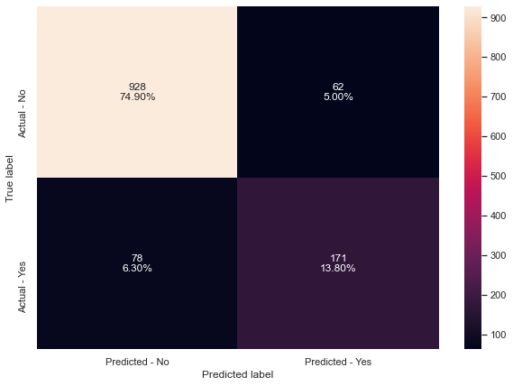

```python
make_confusion_matrix(dtree,y_test)
```

## Hyperparameter Tuning

### Bagging Classifier

```python
# Choose the type of classifier.
bagging_estimator_tuned = BaggingClassifier(random_state=1)

# Grid of parameters to choose from
## add from article
parameters = {'max_samples': [0.7,0.8,0.9],
              'max_features': [0.8,0.9,1],
              'n_estimators' : [20,35,50],
             }

# Type of scoring used to compare parameter combinations
acc_scorer = metrics.make_scorer(metrics.recall_score)

# Run the grid search
grid_obj = GridSearchCV(bagging_estimator_tuned, parameters, scoring=acc_scorer,cv=4)
grid_obj = grid_obj.fit(X_train, y_train)

# Set the clf to the best combination of parameters
bagging_estimator_tuned = grid_obj.best_estimator_

# Fit the best algorithm to the data.
bagging_estimator_tuned.fit(X_train, y_train)
```

```
BaggingClassifier(max_features=0.9, max_samples=0.9, n_estimators=35,
                  random_state=1)
```

**Let's check different metrics for bagging classifier with best hyperparameters and build a confusion matrix.**

```python
#Using above defined function to get accuracy, recall and precision on train and test set
bagging_estimator_tuned_score=get_metrics_score(bagging_estimator_tuned)
```

```
Accuracy on training set :  0.9989615784008308
Accuracy on test set :  0.9047619047619048
Recall on training set :  0.9945255474452555
Recall on test set :  0.6104417670682731
Precision on training set :  1.0
Precision on test set :  0.8786127167630058
```

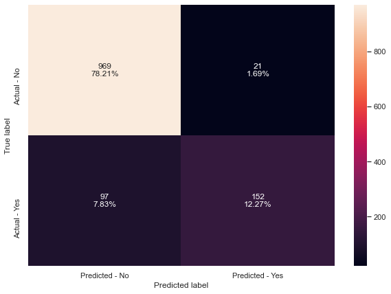

```python
make_confusion_matrix(bagging_estimator_tuned,y_test)
```

### Let's try using logistic regression as the base estimator for bagging classifier:

- Now, let's try and change the 'base_estimator' of the bagging classifier, which is a decision tree by default.
- We will pass the logistic regression as the base estimator for bagging classifier.

```python
bagging_lr=BaggingClassifier(base_estimator=LogisticRegression(random_state=1),random_state=1)
bagging_lr.fit(X_train,y_train)
```

```
BaggingClassifier(base_estimator=LogisticRegression(random_state=1),
                  random_state=1)
```

```python
#Using above defined function to get accuracy, recall and precision on train and test set
bagging_lr_score=get_metrics_score(bagging_lr)
```

```
Accuracy on training set :  0.829698857736241
Accuracy on test set :  0.8337368845843423
Recall on training set :  0.20985401459854014
Recall on test set :  0.24497991967871485
Precision on training set :  0.6609195402298851
Precision on test set :  0.7721518987341772
```

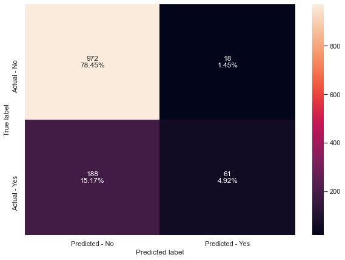

```python
make_confusion_matrix(bagging_lr,y_test)
```

### Insights

- Bagging classifier with hyperparameter tuning (many attempts and grid of parameters used) does not improve in a significant form the behavior of the model. Only it is obtained a bit increase in the recall.
- Bagging classifier with logistic regression as base_estimator is not overfitting the data but the test recall is very low.
- In conclusion, for this case, the hyperparameter tuning for bagging classifier does not offer any advantage.

### Random Forest Classifier

**Now, let's see if we can get a better model by tuning the random forest classifier.**

```python
# Choose the type of classifier.
rf_estimator_tuned = RandomForestClassifier(random_state=1)

# Grid of parameters to choose from
## add from article
parameters = {"n_estimators": [80,100,120],
              "min_samples_leaf": [2,3,4],
              "max_features": [0.7,0.8,0.9],
              "max_samples": [0.7,0.8,0.9],
             }

# Type of scoring used to compare parameter combinations
acc_scorer = metrics.make_scorer(metrics.recall_score)

# Run the grid search
grid_obj = GridSearchCV(rf_estimator_tuned, parameters, scoring=acc_scorer,cv=4)
grid_obj = grid_obj.fit(X_train, y_train)

# Set the clf to the best combination of parameters
rf_estimator_tuned = grid_obj.best_estimator_

# Fit the best algorithm to the data.
rf_estimator_tuned.fit(X_train, y_train)
```

```
RandomForestClassifier(max_features=0.9, max_samples=0.9, min_samples_leaf=2,
                       n_estimators=80, random_state=1)
```

```python
#Using above defined function to get accuracy, recall and precision on train and test set
rf_estimator_tuned_score=get_metrics_score(rf_estimator_tuned)
```

```
Accuracy on training set :  0.9816545517480096
Accuracy on test set :  0.8861985472154964
Recall on training set :  0.9124087591240876
Recall on test set :  0.5622489959839357
Precision on training set :  0.9900990099009901
Precision on test set :  0.813953488372093
```

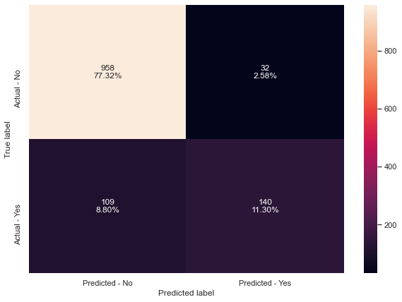

```python
make_confusion_matrix(rf_estimator_tuned,y_test)
```

### Insights

- The model accuracy has decreased a bit because the overfitting has also been reduced.
- The train and test recall have not improved significantly.
- We can see from the confusion matrix that the random forest model with parameter tuning has not a better performance than without this possibility.

### Checking the feature importance

- To check the importance of the different features in a model, we plot here for the case of the random forest model with parameter tuning.

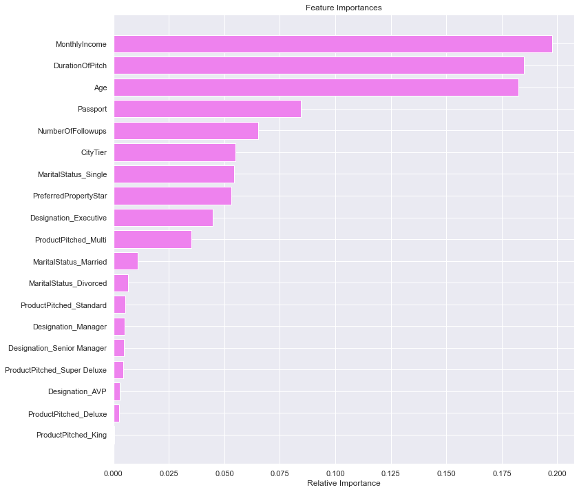

```python
importances = rf_estimator_tuned.feature_importances_
indices = np.argsort(importances)
feature_names = list(X.columns)

plt.figure(figsize=(12,12))
plt.title('Feature Importances')
plt.barh(range(len(indices)), importances[indices], color='violet', align='center')
plt.yticks(range(len(indices)), [feature_names[i] for i in indices])
plt.xlabel('Relative Importance')
plt.show()
```

- Checking the most important features to take a product: MonthlyIncome, DurationOfPitch and Age.
- The single and executive customers are the best customers to take a product.
- The multi_product is the most relatively taken product by the customers.

### Comparing all models till now

```python
# defining list of models
models = [bagging_estimator,bagging_estimator_tuned,bagging_lr,rf_estimator,rf_estimator_tuned]

# defining empty lists to add train and test results
acc_train = []
acc_test = []
recall_train = []
recall_test = []
precision_train = []
precision_test = []

# looping through all the models to get the accuracy, recall and precision scores
for model in models:
    j = get_metrics_score(model,False)
    acc_train.append(np.round(j[0],2))
    acc_test.append(np.round(j[1],2))
    recall_train.append(np.round(j[2],2))
    recall_test.append(np.round(j[3],2))
    precision_train.append(np.round(j[4],2))
    precision_test.append(np.round(j[5],2))
```

```python
comparison_frame = pd.DataFrame({'Model':['Bagging classifier with default parameters','Tuned Bagging Classifier',
                                        'Bagging classifier with base_estimator=LR', 'Random Forest with deafult parameters',
                                         'Tuned Random Forest Classifier'],
                                          'Train_Accuracy': acc_train,'Test_Accuracy': acc_test,
                                          'Train_Recall':recall_train,'Test_Recall':recall_test,
                                          'Train_Precision':precision_train,'Test_Precision':precision_test})
comparison_frame
```

|  | Model | Train_Accuracy | Test_Accuracy | Train_Recall | Test_Recall | Train_Precision | Test_Precision |
| --- | --- | --- | --- | --- | --- | --- | --- |
| 0 | Bagging classifier with default parameters | 0.99 | 0.90 | 0.96 | 0.61 | 1.00 | 0.83 |
| 1 | Tuned Bagging Classifier | 1.00 | 0.90 | 0.99 | 0.61 | 1.00 | 0.88 |
| 2 | Bagging classifier with base_estimator=LR | 0.83 | 0.83 | 0.21 | 0.24 | 0.66 | 0.77 |
| 3 | Random Forest with deafult parameters | 1.00 | 0.90 | 1.00 | 0.56 | 1.00 | 0.88 |
| 4 | Tuned Random Forest Classifier | 0.98 | 0.89 | 0.91 | 0.56 | 0.99 | 0.81 |

### Final remarks for these models:

- Hyperparameter tuning is tricky and exhaustive in the sense that there is no direct way to calculate how a change in the hyperparameter value will reduce the loss of your model until you try those hyperparameters.
- The final results depend on the parameters used/checked using GridSearchCV.
- There may be yet better parameters which may result in a better accuracy and recall.
- In view of this table, for this case, the Tuned Bagging Classifier offers the best performance, even though, without any tuning, the decision tree can offer a similar performance if the recall is taken as the important parameter of the model.

## Model Building - Boosting

- Build Adaboost, gradient boost, xgboost and stacking classifier

### Model performance evaluation and improvement

- Comment on which metric is right for model performance evaluation and why? - Comment on model performance - Can model performance be improved? check and comment

### AdaBoost Classifier

```python
abc = AdaBoostClassifier(random_state=1)
abc.fit(X_train,y_train)
```

```
AdaBoostClassifier(random_state=1)
```

```python
#Using above defined function to get accuracy, recall and precision on train and test set
abc_score=get_metrics_score(abc)
```

```
Accuracy on training set :  0.8480443059882312
Accuracy on test set :  0.8305084745762712
Recall on training set :  0.3302919708029197
Recall on test set :  0.3293172690763052
Precision on training set :  0.7154150197628458
Precision on test set :  0.656
```

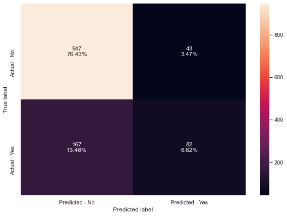

```python
make_confusion_matrix(abc,y_test)
```

### Insights

- The model performance has decreased in all the parameters.
- This model is not recomendable.

### GradientBoost Classifier

```python
gbc = GradientBoostingClassifier(random_state=1)
gbc.fit(X_train,y_train)
```

```
GradientBoostingClassifier(random_state=1)
```

```python
#Using above defined function to get accuracy, recall and precision on train and test set
gbc_score=get_metrics_score(gbc)
```

```
Accuracy on training set :  0.8861197646244375
Accuracy on test set :  0.8539144471347861
Recall on training set :  0.4854014598540146
Recall on test set :  0.3855421686746988
Precision on training set :  0.8498402555910544
Precision on test set :  0.7741935483870968
```

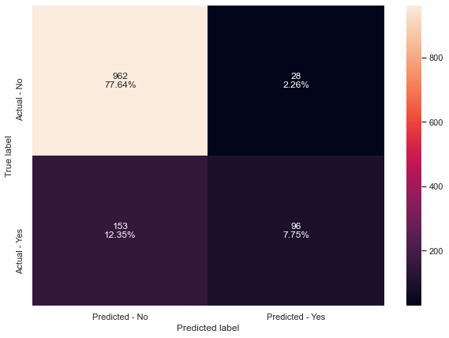

```python
make_confusion_matrix(gbc,y_test)
```

### Insights

- The model performance has decreased in all the parameters.
- This model is not recomendable.

### XGBoost Classifier

```python
xgb = XGBClassifier(random_state=1,objective='binary:logistic',eval_metric='logloss')
xgb.fit(X_train,y_train)
```

```
XGBClassifier(base_score=0.5, booster='gbtree', colsample_bylevel=1,
              colsample_bynode=1, colsample_bytree=1, eval_metric='logloss',
              gamma=0, gpu_id=-1, importance_type='gain',
              interaction_constraints='', learning_rate=0.300000012,
              max_delta_step=0, max_depth=6, min_child_weight=1, missing=nan,
              monotone_constraints='()', n_estimators=100, n_jobs=4,
              num_parallel_tree=1, random_state=1, reg_alpha=0, reg_lambda=1,
              scale_pos_weight=1, subsample=1, tree_method='exact',
              validate_parameters=1, verbosity=None)
```

```python
#Using above defined function to get accuracy, recall and precision on train and test set
xgb_score=get_metrics_score(xgb)
```

```
Accuracy on training set :  0.9941156109380408
Accuracy on test set :  0.9079903147699758
Recall on training set :  0.9708029197080292
Recall on test set :  0.642570281124498
Precision on training set :  0.99812382739212
Precision on test set :  0.8648648648648649
```

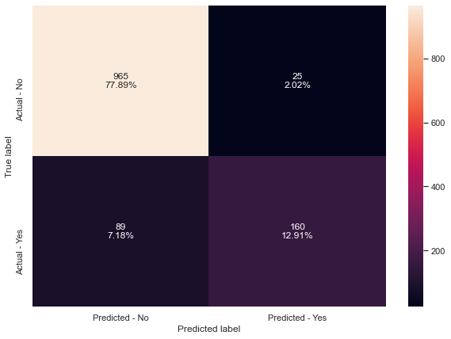

```python
make_confusion_matrix(xgb,y_test)
```

### Insights

- The model performance has improved in the recall parameter.
- This model can be recomendable and it will be the only one we will make now the tuning of the parameters.

## Hyperparameter Tuning

### XGBoost Classifier

**XGBoost has many hyper parameters which can be tuned to increase the model performance**

```python
# Choose the type of classifier.
xgb_tuned = XGBClassifier(random_state=1,objective='binary:logistic',eval_metric='logloss')

# Grid of parameters to choose from
## add from
parameters = {
    "n_estimators": [80,100],
    "scale_pos_weight":[1,2],
    "subsample":[0.7,0.8,0.9],
    "learning_rate":[0.05,0.1],
    "gamma":[0,1],
    "colsample_bytree":[0.5,0.7,0.9],
    "colsample_bylevel":[0.5,0.7,0.9]
}

# Type of scoring used to compare parameter combinations
acc_scorer = metrics.make_scorer(metrics.recall_score)

# Run the grid search
grid_obj = GridSearchCV(xgb_tuned, parameters,scoring=acc_scorer,cv=5)
grid_obj = grid_obj.fit(X_train, y_train)

# Set the clf to the best combination of parameters
xgb_tuned = grid_obj.best_estimator_

# Fit the best algorithm to the data.
xgb_tuned.fit(X_train, y_train)
```

```
XGBClassifier(base_score=0.5, booster='gbtree', colsample_bylevel=0.9,
              colsample_bynode=1, colsample_bytree=0.9, eval_metric='logloss',
              gamma=0, gpu_id=-1, importance_type='gain',
              interaction_constraints='', learning_rate=0.1, max_delta_step=0,
              max_depth=6, min_child_weight=1, missing=nan,
              monotone_constraints='()', n_estimators=100, n_jobs=4,
              num_parallel_tree=1, random_state=1, reg_alpha=0, reg_lambda=1,
              scale_pos_weight=2, subsample=0.9, tree_method='exact',
              validate_parameters=1, verbosity=None)
```

```python
#Using above defined function to get accuracy, recall and precision on train and test set
xgb_tuned_score=get_metrics_score(xgb_tuned)
```

```
Accuracy on training set :  0.9747317410868813
Accuracy on test set :  0.8894269572235673
Recall on training set :  0.9361313868613139
Recall on test set :  0.6385542168674698
Precision on training set :  0.9310344827586207
Precision on test set :  0.7718446601941747
```

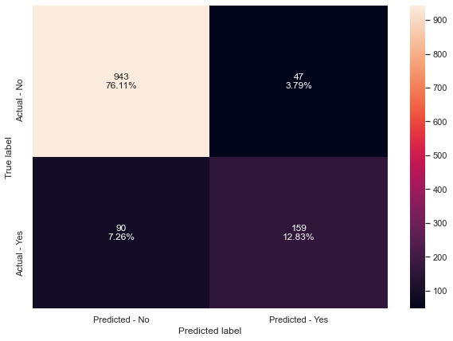

```python
make_confusion_matrix(xgb_tuned,y_test)
```

### Insights

- The tuned model is not offering any advantage over the non tuned model.

### Checking the feature importance

- To check the importance of the different features in a model, we plot here for the case of the xgb model.

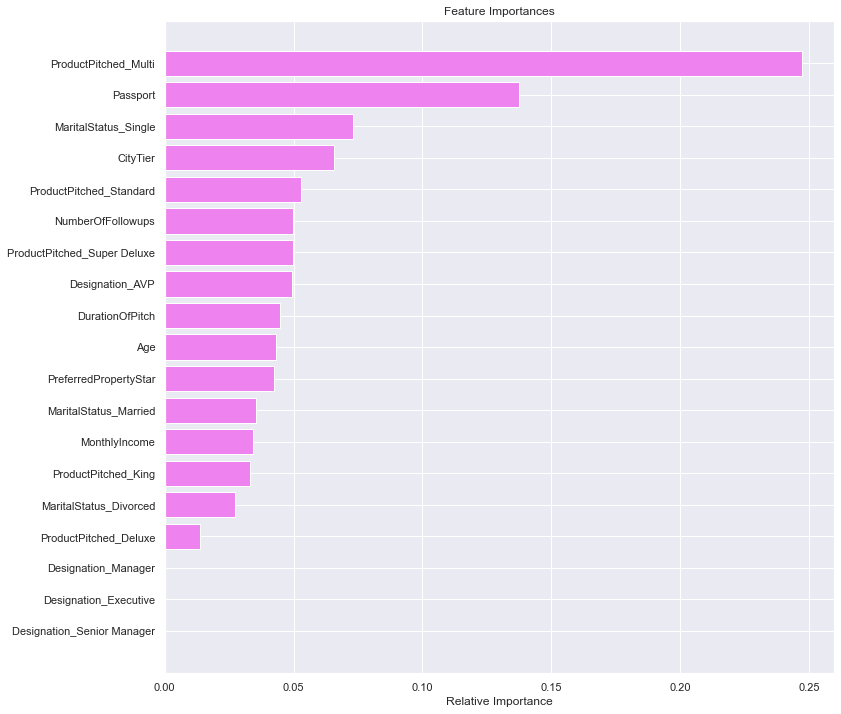

```python
importances = xgb.feature_importances_
indices = np.argsort(importances)
feature_names = list(X.columns)

plt.figure(figsize=(12,12))
plt.title('Feature Importances')
plt.barh(range(len(indices)), importances[indices], color='violet', align='center')
plt.yticks(range(len(indices)), [feature_names[i] for i in indices])
plt.xlabel('Relative Importance')
plt.show()
```

- Checking to have passport and offering the multi product to single customers is the best strategy to have success according to this model.

## Stacking Model

**Now, let's build a stacking model with the models with better recall performance: decision tree, bagging classifier and XG boosting, then use XGBoost to get the final prediction.**

```python
estimators=[('Decision Tree', dtree),('Bagging Classifier', bagging_estimator),
           ('XGradient Boosting', xgb)]
final_estimator=XGBClassifier(random_state=1,objective='binary:logistic',eval_metric='logloss')
```

```python
stacking_estimator=StackingClassifier(estimators=estimators, final_estimator=final_estimator,cv=4)
stacking_estimator.fit(X_train,y_train)
```

```
StackingClassifier(cv=4,
                   estimators=[('Decision Tree',
                                DecisionTreeClassifier(random_state=1)),
                               ('Bagging Classifier',
                                BaggingClassifier(random_state=1)),
                               ('XGradient Boosting',
                                XGBClassifier(base_score=0.5, booster='gbtree',
                                              colsample_bylevel=1,
                                              colsample_bynode=1,
                                              colsample_bytree=1,
                                              eval_metric='logloss', gamma=0,
                                              gpu_id=-1, importance_type='gain',
                                              interaction_co...
                                                 importance_type='gain',
                                                 interaction_constraints=None,
                                                 learning_rate=None,
                                                 max_delta_step=None,
                                                 max_depth=None,
                                                 min_child_weight=None,
                                                 missing=nan,
                                                 monotone_constraints=None,
                                                 n_estimators=100, n_jobs=None,
                                                 num_parallel_tree=None,
                                                 random_state=1, reg_alpha=None,
                                                 reg_lambda=None,
                                                 scale_pos_weight=None,
                                                 subsample=None,
                                                 tree_method=None,
                                                 validate_parameters=None,
                                                 verbosity=None))
```

```python
#Using above defined function to get accuracy, recall and precision on train and test set
stacking_estimator_score=get_metrics_score(stacking_estimator)
```

```
Accuracy on training set :  0.9865005192107996
Accuracy on test set :  0.9047619047619048
Recall on training set :  0.9671532846715328
Recall on test set :  0.6265060240963856
Precision on training set :  0.9618874773139746
Precision on test set :  0.861878453038674
```

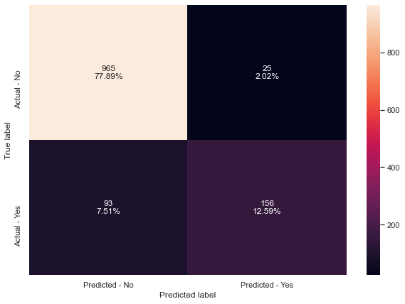

```python
make_confusion_matrix(stacking_estimator,y_test)
```

### Insights

- We have in this stack model a light improvement for precision of the model.
- The important parameter, the recall, is neither improved in this final attempt.

## Comparing all models

```python
# defining list of models
models = [dtree,bagging_estimator,bagging_lr,bagging_estimator_tuned,rf_estimator,rf_estimator_tuned,abc,gbc,
          xgb,xgb_tuned,stacking_estimator]

# defining empty lists to add train and test results
acc_train = []
acc_test = []
recall_train = []
recall_test = []
precision_train = []
precision_test = []

# looping through all the models to get the accuracy, recall and precision scores
for model in models:
    j = get_metrics_score(model,False)
    acc_train.append(np.round(j[0],2))
    acc_test.append(np.round(j[1],2))
    recall_train.append(np.round(j[2],2))
    recall_test.append(np.round(j[3],2))
    precision_train.append(np.round(j[4],2))
    precision_test.append(np.round(j[5],2))
```

```python
comparison_frame = pd.DataFrame({'Model':['Decision Tree','Bagging Classifier','Bagging with LR','Bagging tuned',
                                          'Random Forest','Tuned Random Forest',
                                          'AdaBoost Classifier', 'Gradient Boosting',
                                          'XGBoost Classifier',  'Tuned XGBoost','Stacking Model'],
                                          'Train_Accuracy': acc_train,'Test_Accuracy': acc_test,
                                          'Train_Recall':recall_train,'Test_Recall':recall_test,
                                          'Train_Precision':precision_train,'Test_Precision':precision_test})
comparison_frame
```

|  | Model | Train_Accuracy | Test_Accuracy | Train_Recall | Test_Recall | Train_Precision | Test_Precision |
| --- | --- | --- | --- | --- | --- | --- | --- |
| 0 | Decision Tree | 1.00 | 0.89 | 1.00 | 0.69 | 1.00 | 0.73 |
| 1 | Bagging Classifier | 0.99 | 0.90 | 0.96 | 0.61 | 1.00 | 0.83 |
| 2 | Bagging with LR | 0.83 | 0.83 | 0.21 | 0.24 | 0.66 | 0.77 |
| 3 | Bagging tuned | 1.00 | 0.90 | 0.99 | 0.61 | 1.00 | 0.88 |
| 4 | Random Forest | 1.00 | 0.90 | 1.00 | 0.56 | 1.00 | 0.88 |
| 5 | Tuned Random Forest | 0.98 | 0.89 | 0.91 | 0.56 | 0.99 | 0.81 |
| 6 | AdaBoost Classifier | 0.85 | 0.83 | 0.33 | 0.33 | 0.72 | 0.66 |
| 7 | Gradient Boosting | 0.89 | 0.85 | 0.49 | 0.39 | 0.85 | 0.77 |
| 8 | XGBoost Classifier | 0.99 | 0.91 | 0.97 | 0.64 | 1.00 | 0.86 |
| 9 | Tuned XGBoost | 0.97 | 0.89 | 0.94 | 0.64 | 0.93 | 0.77 |
| 10 | Stacking Model | 0.99 | 0.90 | 0.97 | 0.63 | 0.96 | 0.86 |

- Bagging tuned model and stacking model offer good results for the recall with a high test_precision.
- The decision tree can be the simplest model to use with the highest score for the recall, although with a lower test_precision.

## Business Recommendations

- Compare models - Business recommendations and insights

**Relative to the costumers:**

- The most important features to take a product seem to be: MonthlyIncome, DurationOfPitch and Age.
- Also to have passport and the singleness state of the costumers are important to take into account.
- The single and executive customers are the best customers to take a product.
- The multi_product is the most relatively taken product by the customers.

**Relative to the best models:**

- Bagging tuned model and stacking model offer good results for the recall with a high test_precision.
- The decision tree can be the simplest model to use with the highest score for the recall, although with a lower test_precision.